# Twitter Rest API

paul

March 14, 2017

### Tools and Packages:

- [Apigee Twitter API Console](https://apigee.com/console/twitter)
  - Useful interface to test out queries to the API.
- [twitteR](https://cran.r-project.org/web/packages/twitteR/twitteR.pdf)
- [twitteR Vignette](http://geoffjentry.hexdump.org/twitteR.pdf)
  - **Highly Recommanded to Read**

### First Look at *twitteR*:

- The package provides methods for parsing returned data.
- Methods to setup, store, load twitter data bases.
- Classes/objects wrappersto represent twitter objects.
  - includes functions to convert to Data frames.
- Extracting personal data:
  - favorites
  - friendships
  - direct messages
- Public data:
  - trends
  - public tweets
  - retweets
  - search Twitter
- Create access tokens (handling handshake between brower and Twitter Server)
- Many customizable parameters.
  - Abstracts away from retrying in case of rate limit
  - Abstracts away from manual navigation of cursors
- Uncertain as to how to access the *.httr-oauth*

### Tweeter Limits And Information:

- Can extract up to a maximum 3200 statuses from a user Timeline.
  - Each page of response can contain up to 200 results.
- For search/tweets, each page of response can contain up to 100 tweets.
- The *source owner* is mentioned in the text of the tweet (status in twitteR package) by an _@_ sign followed by the source owner of the tweet.

### Example 1: Creating a Word Cloud From Twitter

**GOAL: To test out the *twitteR* package’s ability to scrape public twitter data.**

- [Google Building wordCloud](https://sites.google.com/site/miningtwitter/questions/talking-about/wordclouds/wordcloud1)
- [Building wordCloud](https://www.r-bloggers.com/building-wordclouds-in-r/)
- [Using tm Package](https://cran.r-project.org/web/packages/tm/vignettes/tm.pdf)

1: Import Libraries and getting Access Token

```r
    rm(list = ls())

    library(twitteR)
    library(httr)

    library(tm)
    library(wordcloud)
    library(SnowballC)
    library(RColorBrewer)
```

```r
    # access Tokens
    consumer_Key = "oQ3PqERg75kPtgBcgOLaFShSC"
    consumer_Secret = "d4cxaKc1Dt3ugagruUNPtWzvmqGHx8WvwYAQ8MywUqTIVTTj9O"
    access_Token = "833674399224061952-tL4gGOyGUrz84IbVlkkAmQzqUPahL1N"
    access_Secret = "qkNmkD7TU5uZtIENW3r5K20wkqfbL6w37xyXLwelYBZg6"


    ##  Intially, the function asks the user to cache the credentials and
    ##  will be used for another session.
    setup_twitter_oauth(consumer_Key,consumer_Secret,access_Token,access_Secret)
```

```
## [1] "Using direct authentication"
```

```r
    ##  Creating a token
    app <- oauth_app("twitter", key=consumer_Key, secret=consumer_Secret)

    token = Token1.0$new(endpoint = NULL, params = list(as_header = TRUE),
                                app = app, credentials = list(oauth_token = access_Token,
                      oauth_token_secret = access_Secret))
    saveRDS(token,"tokenTest")
    test_Token = readRDS("tokenTest")

    ## token and test_Token are the same object.

    ## loading cached token from twitteR package:
    ##  It failed, likely because of the output format.
    ##  The file size is 0KB
   # oauth_content <- readRDS('.httr-oauth')
```

2: Getting Raw Data

```r
    search_String = "NRC+OR+#NRC+OR+@NRC"
    lang = "en"
    since = "2016-01-01"


    ##  Extracting coordinates for center of Canada:
    google_Api_Key = "AIzaSyBGTs-gZCbyP8n0Hvw_VZ76Z6YrST1DNa8"
    google_Host = "https://maps.googleapis.com/maps/api"

    request = paste(google_Host,"/geocode/json",
                    "?address=Canada&key=",
                    google_Api_Key,sep="")
    raw= GET(request)

    data = jsonlite::fromJSON(
       httr:: content(raw,as="text")
        )
    lat = data$results$geometry$location["lat"]
    lng = data$results$geometry$location["lng"]

    geocode =paste(lat,lng,"2000km",sep=",")



    ##  A list of tweets in Ottawa mentioning NRC. Note, the return
    ## already a "status"
    NRC_Search = searchTwitter(search_String, n=200,
                               lang=lang, since=since,geocode =geocode)

    ##  Does allow the specification of "untruncated tweets"
    ##  This was done manually.


    ##  Many tweets are truncated. Getting a list
    ## of ids for tweets that have been truncated.

    truncated_Id = lapply(NRC_Search, function(x)
            {
                if(x$truncated)
                   return(x$id)
                else
                    return(NA)
            }
        )

    version = 1.1
    cmd = "/statuses/show/"
    param = "?tweet_mode=extended"

    search_Id = truncated_Id[
        !is.na(truncated_Id)]

    long_Tweet = list();

    ##  Getting Untruncated tweets
    ##  Going to use traditionall get methods
    for(i in 1:length(search_Id))
    {
        url = paste("https://api.twitter.com/",
                    version,cmd,
                    search_Id[i],".json",
                    param, sep="")

        ##getting raw response
        raw_Response = GET(url,config=token)

        ##  expanded
        long_Tweet[[i]] = jsonlite::fromJSON(
            httr::content(raw_Response,"text")
        )

    }


    truncated_Id[!is.na(truncated_Id)] = long_Tweet

    ## Organized texts results
    for(i in 1:length(NRC_Search)){
        if(NRC_Search[[i]]$truncated){
            NRC_Search[[i]] = truncated_Id[[i]]

        }
    }


    ## removing twitter links
    text_NRC = lapply(NRC_Search, function(x)
            {
                text = x$text
                ## converting to ASCII
                text= iconv(x=text,from="UTF-8",to="ASCII",sub="")

                ##Clearning out URLs
                text=gsub("http(s?)://t.co/[a-zA-Z0-9]+",
                     "",text)
                text=gsub("\nhttps:","",text)
            }
        )



     rm(list = setdiff(ls(),c("token","text_NRC")))
```

3: Make the word Map

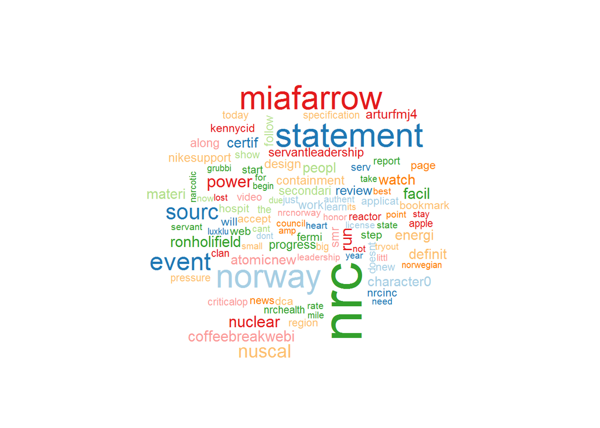

```r
    require(twitteR)
    ##  Constructing corpus (structure to process text)
    cor= Corpus(VectorSource(text_NRC))
    cor = tm_map(cor,removePunctuation)
    cor = tm_map(cor, removeWords,stopwords('english'))
    cor = tm_map(cor,stemDocument)



    ## Some words may appear to be missing characters
    ## This is due to the stem analysis function.

    wordcloud(cor,max.words = 100,random.color=T,random.order = T,
              colors =brewer.pal(8,"Paired") )
```

### REST API Example 2: Random Exploration

```r
    ## Useful for examining rate
    ## remaining in 15 window
    rate_Limit = getCurRateLimitInfo()
```

1: Friendships and Users * **The *lookupUsers* and *friendships* function behaves as specified by the documentation.**

2: Favorites: **The *favorites* function behaves as specified by the documentation.**

3: Trending Section of Twitter: * **the trending section describes the popular live disscussions and behaves as the documentation specifies.**

### Example 3: DataBase Connection Functions of twitteR:

- The functionality provided by twitteR package behaves as the documentation outlines. To view testing code, refer to the *Twitter Rest API.Rmd* file.

```r
    library(twitteR)
    search_Data = searchTwitter(searchString="sports",n=10,
                                lang="en")

    db_Data = twitteR::twListToDF(search_Data)

      ##sorting text in search_Data
    for(i in 1: length(db_Data$text)){
        db_Data[[i]] = gsub(pattern="\n", replacement = " ",
                            db_Data[[i]])
    }

    if(!file.exists("DB_Data.txt"))
    {
        file.create("DB_Data.txt")

    }

     write.table(db_Data, file="./DB_Data.txt",row.names = F,
                fileEncoding = "UTF-8",sep="\t",col.names=F)
```

```r
require(RMySQL)
require(twitteR)
```

```r
    db_name = "twitterdb"
    user = "root"
    host ="localhost"
    password = "19970728Paul$"

    ## sets up a connection
    DBI = register_mysql_backend(db_name,host,user,password)

    ## returns a list of twitteR status
    loaded_Data = load_tweets_db(table_name = "status")
    paste("Length", length(loaded_Data))
```

```
## [1] "Length 26"
```

```r
    ## Trying to store tweets into the same db:
      search_Data2 = searchTwitter(searchString="#glee",n=10,
                                lang="en")

    ## The new data is appended to the bottom
    store_tweets_db(search_Data2,table_name="status")
```

```
## [1] TRUE
```

```r
    loaded_Data = load_tweets_db(table_name = "status")
    paste("Length", length(loaded_Data))
```

[output not shown]

### Evaluation of *twitteR*:

- The built in class wrappers provides convient and organized information.
  - functions associated with these class are very useful.
- The built in function provides substantial details and is shown in an easily accessible way.
- Unlike facebook, many users are public and thus the account details are easily accessed.
- High level of abstraction, easy to use but rather hard to change inner workings.